# Infections of the body and the mind

**by [Julio Amador Diaz Lopez](https://www.imperial.ac.uk/people/j.amador)[^1] and [Ralf Martin](https://www.imperial.ac.uk/people/r.martin)[^2]**

Last update: April 22 , 2020 - 14:02

# Introduction

The coronavirus pandemic has changed everything overnight. Unfortunately, as the genetic sequence of the virus started to make its deadly journey through bodies around the world, in parallel a memetic sequence emerged in the minds of some people: the idea that covid19 pandemic is not real and a hoax. Indeed, the worry is that the two infections exist in a symbiotic relationship with one helping to advance the survival and spread of the other. Here we report on our ongoing efforts to map the spread of memetic infection using Twitter. Since March 23 we have been sampling tweets mentioning the terms “corona” and/or “covid”. Currently, we have collected 11.95 million tweets.

# Hoaxism over time

How bad is the hoax infection and is it getting better or worse? To identify tweeters believing in the hoax (or promoting the hoax idea) we look for tweets with one of the following hastags:

- “#hoax”
- “#coronahoax”
- “#covidhoax”

Using hashtags instead of string searches of the same terms provides a good distinction between tweets who display support for hoaxsim vs tweets criticising hoaxism. Note that this is likely a conservative way of counting hoaxist tweets and in reality a larger fraction of tweets are from people supporting hoaxist ideas.

Below is a time series plot of the share of hoaxist tweets over our sample period.[^3]] we report separate series for the Us and UK. Assigning location to tweets is notoriously difficult as most users have switch off detailed location tracking. In the figure below we base location on the analysis of a free text field where users can write something about their whereabouts. In many cases this refers to known areas although the detail varies (e.g. London, UK vs the Universe). Often it also involves phantasy locations (e.g. Walhalla). Hence, our “other” category might include tweeters from either the UK or Us who have chosen not to reveal their location.

Note that towards the begining of the sample period the share of hoax tweets in all covid related tweets is less than 0.5%. However, the weekend around the 28th of March saw a major outbreak of Hoaxism that was particularly bad in the UK. This has subsided somewhat come March 30. The whole sample trend would suggest that hoaxism is fairly stable and not subsiding, although there seems to be a declining trend for the last couple of days.

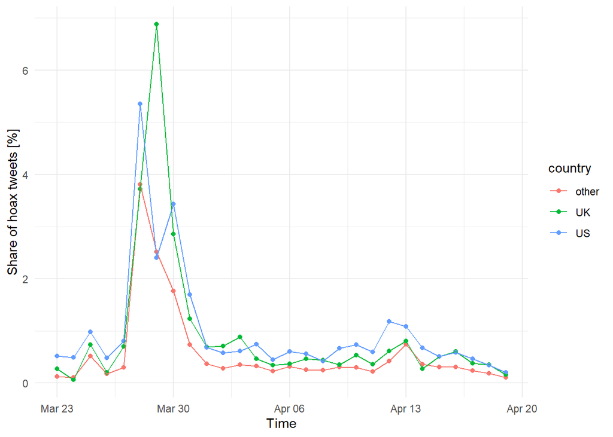

# Why hoaxism?

What are drivers of hoaxism? We can start exploring this by looking at the tweets of hoaxists more widely. Below we plot a word cloud of the last 1000 tweets of the 300 most prolific hoaxists. One hypothesis is that hoaxism has been fueled by Trumpism. Because of worries that a strong response to the pandemic could negatively affect the economy and thereby his re-election chances, he had a vested interest in playing down the crisis. The word cloud confirms that obsession with trump is prevalent among hoxists.

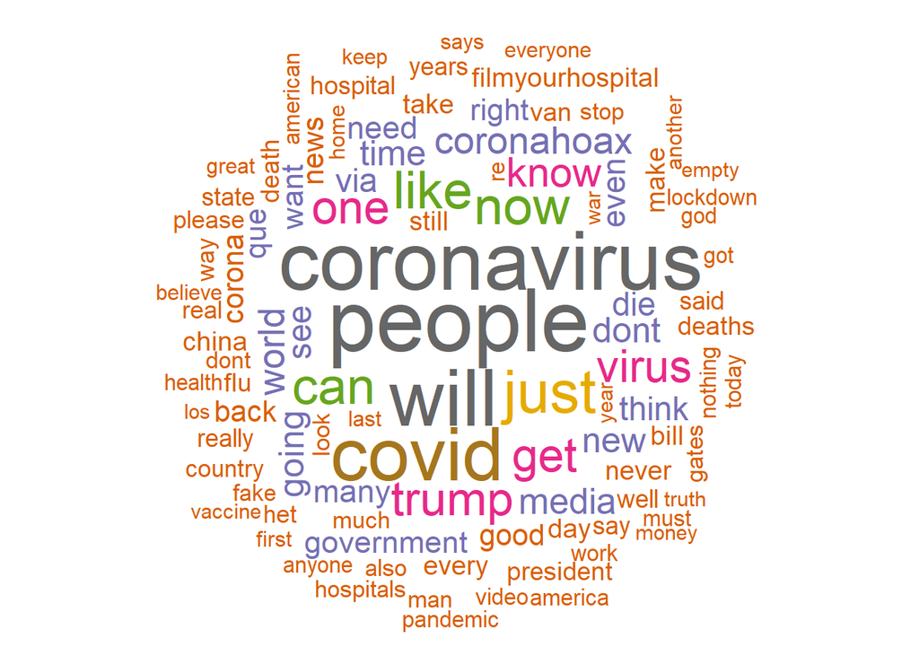

For comparison, here is a word cloud of the 300 most prolific non-hoaxist covid related tweeters. Trump is relevant here too although do a smaller degree: hoaxers have a 4.86 percentage point higher probability of mentioning Trump (The share of Trump mentions across both groups is 5.34%). Of course it might also be that one group is supporting Trump whereas the other is opposing him. We will address this in future work.

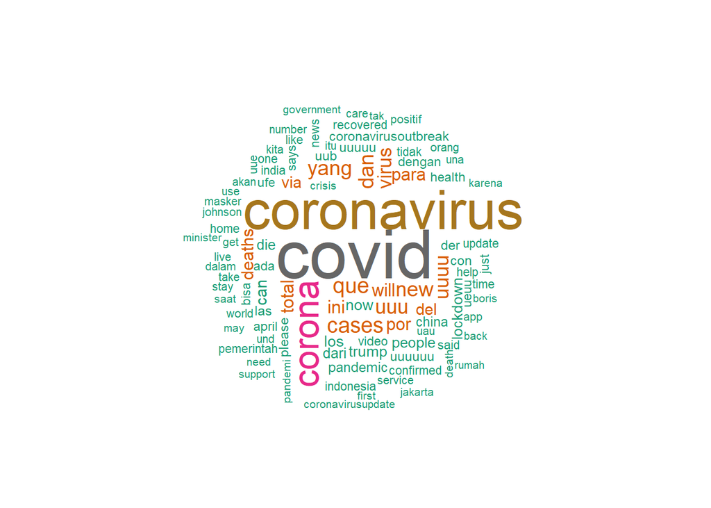

Also note that the term “filmyourhospital” shows up prominently, which according [reports](https://www.mediamatters.org/coronavirus-covid-19/coronavirus-denying-conspiracy-theory-hashtag-spreading-tiktok-infowars-host) is a hastag pushed by right-wing commentators.

# The consequences of memetic infections

We examine if US state level hoax infection rates are correlated with reported covid19 infection rates. This is interesting to gauge if mis-information has any effect on actual outcomes. Clearly, from a simple exercise like that we cannot draw overly strong conclusions about causal effects. However, it is a useful starting point. The figure below[^4] is a scatter plot of state level per capita infection rates on the share of hoax tweets (in percent) from within the state. There is clearly a positive relationship. What is particularly striking is that New York is not only extreme in terms of infections but also in the prevalence of hoaxism.

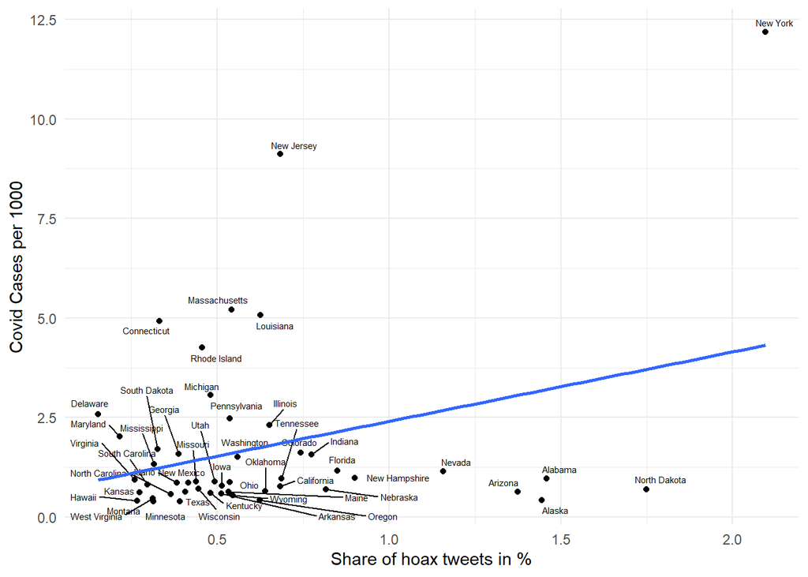

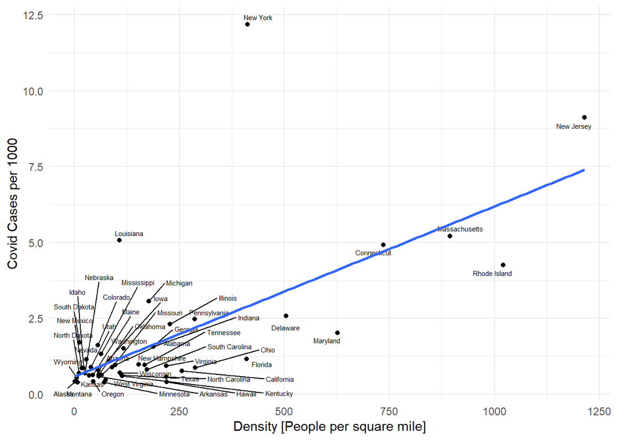

We have to be cautious with causal claims at this stage. Our results could be contingent on our simple model specification or crude aggregation (e.g. we don’t take into account that New York state consists of the metropolitian area of New York as well as rarther rural parts, although as we saw in column 5, the results are not contingent on New York). Still, to understand if the results are not only statistically significant but also quantitatively meaningful it is useful to ask what - if taken at face value - the impact of haoxism would be. Using the estimates from column 4 which we consider our most reliable at this stage would imply that without hoaxism we had 144039 covid cases less (of a total of 722635), as of 2020-04-18. Clearly, this is substantial.

|  | *Dependent variable:* |  |  |  |  |
| --- | --- | --- | --- | --- | --- |
|  | Covid19 Cases per capita |  |  |  |  |
|  | (1) | (2) | (3) | (4) | (5) |
| Hoax Tweets Share | 1.744** | 1.910*** | 2.220*** | 0.184*** | 0.280*** |
|  | (0.774) | (0.568) | (0.426) | (0.048) | (0.037) |
| Population density |  | 0.006*** | -0.001 |  |  |
|  |  | (0.001) | (0.002) |  |  |
| Tweets per capita |  | 0.366 | 0.070 | 0.086*** | 0.004 |
|  |  | (0.407) | (0.307) | (0.008) | (0.007) |
| Hoax X Density |  |  | 0.012*** | 0.002*** | 0.002*** |
|  |  |  | (0.002) | (0.0003) | (0.0002) |
| Tweets X Density |  |  | -0.0002 | 0.0003*** | 0.0003*** |
|  |  |  | (0.001) | (0.00001) | (0.00001) |
| States Controls | No | No | No | Yes | Yes |
| Day Controls | No | No | No | Yes | Yes |
| Sample | Last Day | Last Day | Last Day | Daily | NY dropped |
| Observations | 49 | 49 | 49 | 1,346 | 1,319 |
| R<sup>2</sup> | 0.098 | 0.600 | 0.788 | 0.877 | 0.877 |
| Adjusted R<sup>2</sup> | 0.078 | 0.573 | 0.763 | 0.870 | 0.869 |
| Residual Std. Error | 2.153 | 1.465 | 1.091 | 0.496 | 0.367 |
| F Statistic | 5.079** | 22.496*** | 31.951*** | 114.667*** | 113.115*** |
| *Note:* | p<0.1; p<0.05; p<0.01 |  |  |  |  |

[^1]: Imperial College Business School
[^2]: Imperial College Business School & Centre for Economic Perforamnce, LSE
[^3]: Data is [here](https://mondpanther.github.io/economemics.github.io/data/hoaxshare_over_time.csv)
[^4]: Scatterplot data is [here](https://mondpanther.github.io/economemics.github.io/data/US_scatter.csv).
[^5]: Underlying data is [here](https://mondpanther.github.io/economemics.github.io/data/US_timeseries.csv).